# Car Service and Autonomous Vehicle Model

Brian Gregor

June 22, 2016

## Introduction

This document includes code for estimating and testing the car services and automated vehicle model for the RSPM. The model is used to identify which users will use car services and how many fewer vehicles they will own as a consequence. The model may be used to model conventional car-sharing services or futuristic shared autonomous vehicle (SAV) services. (It can’t do both at the same time.) The model also predicts which households own autonomous vehicles. This model is a substitution for the previous carsharing model that was developed to model the effect of standard carshare services. The model takes a completely different approach from the earlier model as explained below.

This model is run after the vehicle ownership model is run because model needs to ‘know’ the number of vehicles owned by the household. Because of this, the results this model also reflect any vehicle ownership preferences/constraints that are considered by the vehicle ownership model. For example, if a household is identified as owning no vehicles (perhaps because of low income), the car services model does not change that outcome. However, the household will be identified as a user of car services if they are available. The amount of use will be constrained by the household budget however.

The model is also run after the parking model. This is necessary because parking cost, which can be a significant proportion of the cost of using a household vehicle, is avoided if a car service is used instead.

## Setup

```r
library(pander)
```

### Load Survey Data

```r
load("data/MetroHh..RData")
MetroHh..$DrvAgePop <- MetroHh..$Hhsize - MetroHh..$Age0to14
```

### Load DVMT Models

```r
load("data/DvmtLmModels_.RData")
load("data/predictAveDvmt.RData")
```

### Define Function to Load a Cost Parameters File

```r
getParm <- function(FilePathName, Year) {
  Input.. <- read.csv(FilePathName, row.names=1)
  ParmNames. <- rownames(Input..)
  Parm_ <- as.list(Input..[[paste0("X", Year)]])
  names(Parm_) <- ParmNames.
  Parm_
}
```

## Approach

The overall approach to determining which households use car services is to compare the marginal per-mile ownership of each vehicle the household owns with the per-mile cost of using a car service for an equivalent value car. For each household, the increase in VMT with each added car owned is calculated. This is divided into the car ownership cost to calculate the marginal per-mile ownership cost. This cost for each vehicle is compared with the per-mile ‘ownership’ cost of using a car service. The household retains vehicles that have lower marginal costs and eliminates vehicles that have higher marginal costs. Typically when a household gets the first vehicle, their VMT increases much more than when they add subsequent vehicles to their household fleet.

This marginal cost approach is more valid than an average cost approach because households make choices at the margin (to own one more car or one less car), and because vehicle travel and vehicle ownership costs don’t scale uniformly. For example, doubling the number of cars owned does not double the miles driven. This can be seen in the following figure which shows how the average annual miles per driving age person varies with household income and number of household vehicles. The calculations were made from the sample of NHTS (2001) households that reside in metropolitan areas. It can be seen that for most incomes, the miles driven per person are only slightly higher for household owning two cars vs. households only only one car.

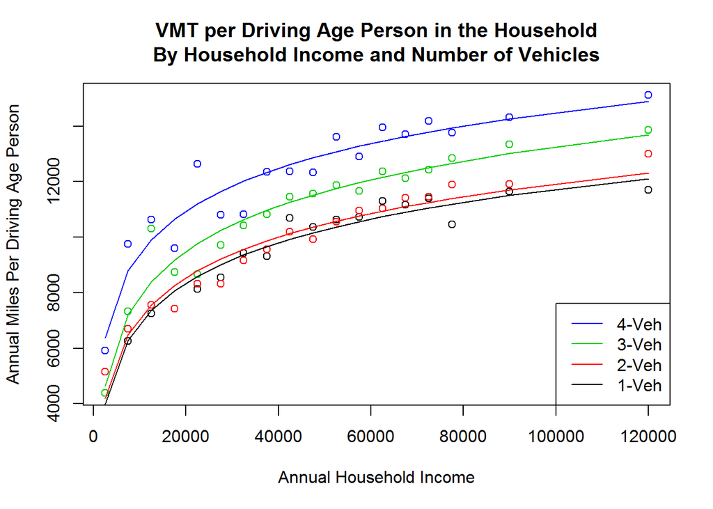

The marginal comparison is made on the basis of household vehicle ownership costs and corresponding car service costs. This includes all costs exclusive of the costs of fuel, tires, and vehicle repair and maintenance (excluding cleaning). These costs (operating costs) are excluded for several reasons:  
1. The per-mile operating costs are likely to be fairly similar for household vehicles and car service vehicles. Differences would be small compared to the ownership costs.  
2. The operating costs are only known after all the household vehicle characteristics and pricing policies are determined by the model. Using operating costs as well as ownership costs would require running the entire model in several iterations, greatly increasing the run time. 3. The purpose of this model is to adjust vehicle ownership.  
4. The use of household vehicles and car services is still limited by the household budget for vehicle operating cost. Therefore, while this model could identify a potential for a significant amount of household travel by car services, the final amount could be less for some households because of household budget constraints.

The methods for calculating the ownership costs are described in the following sections.

## Calculating Household Vehicle Ownership Cost

Household vehicle costs are typically grouped into operating costs and ownership costs. Operating costs vary with the miles driven and include fuel, tire and maintenance costs. Vehicle ownership costs vary with the vehicles owned and not with the miles driven. They include depreciation, financing, insurance, and vehicle licensing/registration/taxes. Following is the approach to calculating each of these costs.  
* Depreciation is the decrease in value of the vehicle with time. According to NADA (2013), vehicles depreciate at about 15% per year (NADA 2013). The actual amount of depreciation depends on the value of the car and the period over which depreciation occurs. The value of the car is set in the input file, but the value should be the same as the value assumed for the car service (exclusive of autonomous vehicle or other special equipment) so that the analysis is consistent. The depreciation period is the first 5 years of the vehicle life, consistent with the approach used by AAA.  
* The financing cost depends on the vehicle cost and interest rate. This can be specified by the user, but the interest rate should be consistent with the value used for calculating car service financing cost. The total financing cost, assuming the 4-year purchase period, is divided by 5 to put it on the same annual basis as the depreciation cost.  
* The insurance amount is fixed at the average vehicle cost published by AAA. It is not varied with vehicle price because insurance rates depend on a number of other factors that may or may not vary with price such as risk of theft and relative vehicle safety. Although AAA estimates vary by vehicle size and type, the variation from the average is relatively small (plus or minus 10%).  
* The vehicle licensing/registration/taxes cost has a stronger relationship to value than insurance. The ratio of AAA estimated cost to estimated vehicle depreciation is about 17% for most of the categories. This ratio is used to calculate the cost.  
* The cost of parking is also included in the ownership cost because it can be a significant cost of using a vehicle that one owns, compared to using a car service.

These ownership costs differ with respect to autonomous vehicles (AV) vs. non-autonomous vehicles. Autonomous vehicles are more costly to purchase because of the added technical equipment required for them to operate autonomously. The cost of autonomous vehicle equipment is a separate line item in the input file. Autonomous vehicles also can produce some cost savings. Autonomous vehicles are likely to have lower insurance costs because they are likely to have lower crash rates and because the cost of crashes when driving autonomously might be the responsibility of the auto manufacturers. Parking cost is also likely to be lower because the autonomous vehicle user will be able to dispatch their vehicle to a lower cost, or free, parking location. There are inputs that can be used to specify these discounts.

The following table lists the input variables in the household ownership cost table and provides a brief description of each:

| Parameter | Example | Description |
| --- | --- | --- |
| VehCost | 20000 | The price of a vehicle comparable to car services |
| AVTechCost | 10000 | The cost of autonomous vehicle technology |
| YearsFinanced | 4 | Number of years vehicle is financed |
| DepreciationRate | 0.15 | Depreciation rate per year (15% = 0.15) |
| InterestRate | 0.05 | Interest rate per year (5% = 0.5) |
| InsuranceCost | 1000 | Annual insurance cost |
| AVInsDiscProp | 0.9 | Discount of insurance cost (0.9 means 10% of cost) |
| AVPkgDiscProp | 0.25 | Discount of parking cost (0.25 means 75% of cost) |
| AVTripVmtAdj | 1.2 | VMT multiplier for AV to account for greater travel comfort and convenience |
| AVRepoVmtAdj | 1.2 | VMT multiplier for AV to account for repositioning travel (e.g. to avoid parking charges) |

```r
#Define function to calculate household vehicle ownership cost
calcAnnVehOwnCost <- function(HhVehOwnParm_, DailyPkgCost = 0,
                              WrkDaysPerYear=260, AutonInsDiscount = 0.5) {
  #Define function to calculate monthly budget, amount financed, and total interest
  calcVehFinancing <- function(VehAmt) {
    Term <- 12 * HhVehOwnParm_$YearsFinanced
    Rate <- HhVehOwnParm_$InterestRate / 12
    MonthlyCost <- VehAmt / ((1 - (1 + Rate)^(-Term)) / Rate)
    Term * MonthlyCost - VehAmt
  }
  #Calculate finance and depreciation cost for non-autonomous vehicles
  NonAutonVehAmt <- HhVehOwnParm_$VehCost
  NonAutonFinance <- calcVehFinancing(NonAutonVehAmt) / 5
  NonAutonDepreciation <- NonAutonVehAmt * (1 - (1 - HhVehOwnParm_$DepreciationRate)^5) / 5
  NonAutonInsurance <- HhVehOwnParm_$InsuranceCost
  NonAutonRegLicTax <- NonAutonDepreciation * 0.17
  NonAutonPkgCost <- DailyPkgCost * WrkDaysPerYear
  NonAutonTot <- NonAutonFinance + NonAutonDepreciation + NonAutonInsurance +
    NonAutonRegLicTax + NonAutonPkgCost
  #Calculate finance and depreciation cost for autonomous vehicles
  if (!is.na(HhVehOwnParm_$AVTechCost)) {
    AutonVehAmt <- HhVehOwnParm_$VehCost + HhVehOwnParm_$AVTechCost
    AutonFinance <- calcVehFinancing(AutonVehAmt) / 5
    AutonDepreciation <- AutonVehAmt * (1 - (1 - HhVehOwnParm_$DepreciationRate)^5) / 5
    AutonInsurance <- HhVehOwnParm_$InsuranceCost * (1 - HhVehOwnParm_$AVInsDiscProp)
    AutonRegLicTax <- AutonDepreciation * 0.17
    AutonPkgCost <- DailyPkgCost * WrkDaysPerYear * (1 - HhVehOwnParm_$AVPkgDiscProp)
    AutonTot <- AutonFinance + AutonDepreciation + AutonInsurance +
      AutonRegLicTax + AutonPkgCost
  } else {
    AutonTot <- NA
  }
  #Return the results for autonomous and non-autonomous vehicles
  list(NonAuton = NonAutonTot, Auton = AutonTot)
}
#Save the function
save(calcAnnVehOwnCost, file="model/calcAnnVehOwnCost.RData")
```

## Calculating the Car Service Mileage Cost

The shared service mileage cost is calculated to be comparable to the household marginal ownership cost. It includes all costs other than fuel, tires, and vehicle maintenance (other than cleaning). The included costs are vehicle price, cost of autonomous vehicle technology, financing, insurance, registration, administrative overhead (e.g. dispatch, billing, …), vehicle cleaning, profit, and contingencies.

The cost per mile depends on the service miles of the vehicle (default is 250,000 miles) and the proportion of miles in non-revenue service due to travel from dropping off one passenger and picking up the next one. Several simulation studies of shared autonomous vehicles have estimated non-revenue service to be about 10% of the total miles. The proportion of non-revenue service increases as population density decreases. The model assumes that the proportion of non-revenue service chances in inverse proportion to the square root of population density (e.g. decreasing density 4 times doubles the proportion of non-revenue service).

The following table lists the input variables in the car service cost table and provides a brief description of each:

| Parameter | Example | Description |
| --- | --- | --- |
| TotSvcMiles | 250,000 | Service life of vehicle in miles |
| RepoProp | 0.1 | Non-revenue mileage proportion at reference density (10% = 0.1) |
| SvcYears | 2 | Service life of vehicle in years |
| VehCost | 20,000 | The price of a vehicle |
| AVTechCost | 10,000 | The cost of autonomous vehicle technology (NA for ordinary car-share) |
| InterestRate | 0.05 | Interest rate per year (5% = 0.5) |
| InsuranceCost | 3000 | Annual cost of insurance |
| Registration | 600 | Annual cost of vehicle registration |
| Overhead | 1000 | Annual overhead cost |
| Cleaning | 5200 | Annual cleaning cost |
| ProfitContingencies | 0.2 | Added proportion for profit/contingencies (20% = 0.2) |
| OccAdj | 1.05 | Average occupancy relative to average occupancy of household vehicles |
| RefDensity | 7000 | Population density corresponding to the specified non-revenue mileage proportion |

```r
#Define function to calculate car service cost per mile
calcCarSvcMileCost <- function(CarSvcCostParm_, PopDen.Hh) {
  if (is.na(CarSvcCostParm_$AVTechCost)) {
    CapCost <- with(CarSvcCostParm_, VehCost * (1 + InterestRate))
  } else {
    CapCost <- with(CarSvcCostParm_, (VehCost + AVTechCost) * (1 + InterestRate))
  }
  OpCost <- with(CarSvcCostParm_, SvcYears *
                  (InsuranceCost + Registration + Overhead + Cleaning))
  TotCost <- (CapCost + OpCost) * (1 + CarSvcCostParm_$ProfitContingencies)
  #Adjust the repositioning proportion
  RepoProp.Hh <- CarSvcCostParm_$RepoProp * sqrt(CarSvcCostParm_$RefDensity / PopDen.Hh)
  #Set repositioning proportion to NA when proportion greater than 1
  RepoProp.Hh[RepoProp.Hh > 1] <- NA
  RevMiles <- with(CarSvcCostParm_, TotSvcMiles * (1 - RepoProp.Hh))
  #Return a list of the cost per mile and a flag of whether is AV or not
  CarSvcMileCost = list(Cost = TotCost / RevMiles,
                        IsAV = !is.na(CarSvcCostParm_$AVTechCost),
                        RepoProp = RepoProp.Hh)
}
save(calcCarSvcMileCost, file = "model/calcCarSvcMileCost.RData")
```

## Identifying Which Households Have Access to Car Services

Whether or not a household uses a car service depends on availability as well as relative cost. The user specifies the proportion of households in each district for whom car service is available. Since districts are fairly small, the values the values will usually be either 1 or 0, but it is possible to specify any proportion in between. Households are chosen randomly based on the proportion. Availability means that the car service can provide service that a household would see as an acceptable substitute for driving their own car (not considering cost).

```r
#Define function to identify which households have car service available
calcCarSvcAvail <- function(Data.., CarSvcAvail.Di) {
  CarSvcAvail.Hh <- CarSvcAvail.Di[Data..$District]
  sapply(CarSvcAvail.Hh, function(x) {
    sample(c(TRUE, FALSE), 1, prob = c(x, 1-x))
  })
}
save(calcCarSvcAvail, file = "model/calcCarSvcAvail.RData")
```

## Adjust Vehicle Ownership, Calculate Car Service Usage, Calculate Autonomous and Non-Autonomous VMT

This model calculates the household choices of whether to own all the vehicles allocated to them by the vehicle ownership model or to own fewer, and use car services for some of their travel, based on a comparison of the marginal vehicle ownership cost per mile and the cost to use a car service. The marginal vehicle ownership cost per mile is calculated by dividing the vehicle ownership cost, as described above, by the marginal VMT for each added car. The marginal VMT for each household is calculated by running the VMT model with 0, 1, 2, and 3 vehicles and then calculating the VMT differences (e.g. difference between VMT with 1 vehicle vs. no vehicles). The model is not run for more than 3 vehicles because testing of the method with more vehicles showed that the marginal VMT for adding more than 3 vehicles is close to the marginal VMT for adding a 3rd vehicle. Therefore, to minimize the number of times the VMT model is run, the marginal VMT for adding the 3rd vehicle is used to calculate the marginal VMT for additional vehicles in households that own more than 3 vehicles. Marginal costs are calculated for both autonomous and non-autonomous vehicles and the choice of which the household will have depends on which has a lower marginal cost. In the case of autonomous vehicles, the marginal VMT is adjusted with the “AVTripVmtAdj” factor to reflect the likelihood that people may travel farther in autonomous vehicles than in non-autonomous vehicles because travel time will be relatively less onerous. The lower of the marginal costs is compared with the calculated car service cost.

Each household that has car service available will be assigned a number of vehicles that is the minimum of the number that is assigned by the vehicle ownership model or the number that has marginal per-mile costs that are less than the per-mile car service cost. In other words, the car services model may only reduce the number of vehicles from what is assigned by the vehicle ownership model.

Households that have available car service may have increased access to vehicles (through the car service) even though they reduce their ownership by eliminating higher marginal cost vehicles. The model assumes that all driving age persons (1)in a household that has available car service would have access to a vehicle, regardless of how many vehicles the household owns. The total vehicle availability for such a household is the maximum of the number of driving age persons in the household and the number of vehicles that are retained by the household. As a result, the availability of car service may increase the amount of car travel even though the number of household vehicles declines, as long as household travel budgets are unconstrained. However, once budget constraints are figured in, the amount of car travel may be reduced because of the greater out-of-pocket cost to use car services.

The model recalculates household VMT using the calculated values for car availability and splits the VMT into VMT that uses household vehicles (autonomous and non-autonomous) and VMT in car services. This is done as follows:  
1. The VMT model is run using the calculation of total car availability instead of cars owned by the household.  
2. The marginal VMT calculation for the household is used to assign the lower marginal cost VMT to household vehicles. The higher marginal cost VMT is assigned to car services.  
3. The household VMT is identified as being either autonomous or non-autonomous based on whether autonomous or non-autonomous vehicles have lower marginal costs.  
4. Likewise the car service VMT is identified as being autonomous or non-autonomous. 5. The VMT of autonomous vehicles is adjusted to reflect the effect that autonomous vehicles may have on total VMT. In the case of autonomous vehicles, VMT may be inflated as a result of the increased comfort of traveling in them and because they may have unoccupied travel (e.g. being sent to a parking lot). The “AVTripVmtAdj” and “AVRepoVMTAdj” factors are used to adjust the VMT. In the case of autonomous car services offering dynamic ride sharing the amount of travel might be reduced due to increased vehicle occupancy (average occupancy greater than the average occupancy for travel in household vehicles).

The calculation of the proportions of autonomous and non-autonomous VMT is also important to calculate the effect on freeway capacity, which also affects the amount of vehicle travel. This is described in the section that follows the code for the vehicle use function.

```r
#Define function to calculate ownership and use of vehicles
calcVehicleUse <- function(Data.., HhVehOwnParm_, CarSvcCostParm_) {

  #Calculate car ownership and car service costs
  #---------------------------------------------
  #Calculate automated and non-automated vehicle ownership cost
  VehOwnCost_ <- calcAnnVehOwnCost(HhVehOwnParm_, DailyPkgCost = Data..$DailyPkgCost,
                                   WrkDaysPerYear=260)
  #Calculate car service mileage cost and if AV or not
  CarSvcMileCost_ <- calcCarSvcMileCost(CarSvcCostParm_, Data..$Hbppopdn)
  CarSvcMileCost.Hh <- CarSvcMileCost_$Cost

  #Calculate marginal VMT per added vehicle
  #----------------------------------------
  #Calculate annual household VMT by number of household vehicles
  Hhvehcnt.Hh <- Data..$Hhvehcnt #Save the household vehicle count
  AnnVmt_Vn.Hh <- list()
  for(i in 0:3) {
    Data..$Hhvehcnt <- i
    AnnVmt_Vn.Hh[[i+1]] <- 365 * predictAveDvmt(Data.., DvmtLmModels_, "Metro")$DvmtAve
  }
  AnnVmt.HhVn <- do.call(cbind, AnnVmt_Vn.Hh)
  #Calculate the marginal VMT for each added vehicle
  NAuMargVmt.HhVn <- t(apply(AnnVmt.HhVn, 1,  diff))
  AuMargVmt.HhVn <- NAuMargVmt.HhVn * HhVehOwnParm_$AVTripVmtAdj

  #Calculate non-autonomous and autonomous marginal ownership cost and
  #Identify lower cost and which is lower
  #-------------------------------------------------------------------
  #Calculate the non-autonomous marginal ownership cost with each added vehicle
  NAuVehOwnCost.Hh <- VehOwnCost_$NonAuton
  NAuMargMileCost.HhVn <- sweep(1/NAuMargVmt.HhVn, 1, NAuVehOwnCost.Hh, "*")
  #Calculate the autonomous marginal ownership cost with each added vehicle
  if (!all(is.na(VehOwnCost_$Auton))) {
    AuVehOwnCost.Hh <- VehOwnCost_$Auton
    AuMargMileCost.HhVn <- sweep(1/AuMargVmt.HhVn, 1, AuVehOwnCost.Hh, "*")
  }
  #Identify lowest marginal cost
  if (!all(is.na(VehOwnCost_$Auton))) {
    IsLowerAuCost.HhVn <- AuMargMileCost.HhVn < NAuMargMileCost.HhVn
    MargMileCost.HhVn <- NAuMargMileCost.HhVn
    MargMileCost.HhVn[IsLowerAuCost.HhVn] <- AuMargMileCost.HhVn[IsLowerAuCost.HhVn]
  } else {
    MargMileCost.HhVn <- NAuMargMileCost.HhVn
  }

  #Calculate the highest number of household vehicles having lower marginal costs
  #------------------------------------------------------------------------------
  #Maximum number of non-automated vehicles that can be owned
  LowMargCost.HhVn <- sweep(MargMileCost.HhVn, 1, CarSvcMileCost.Hh, "-") < 0
  #Set NA to TRUE (because car service not feasible)
  LowMargCost.HhVn[is.na(LowMargCost.HhVn)] <- TRUE
  #Identify the number of vehicles that have lower marginal cost
  MaxMargVeh.Hh <- apply(LowMargCost.HhVn, 1, function(x) {
    max(which(c(TRUE, x))) - 1
  })
  #Types of household vehicles (non-automated or automated)
  if (!all(is.na(VehOwnCost_$Auton))) {
    IsAu.Hh <- apply(IsLowerAuCost.HhVn, 1, function(x) all(x))
  } else {
    IsAu.Hh <- rep(FALSE, nrow(Data..))
  }

  #Identify which households use car service and adjust ownership level
  #--------------------------------------------------------------------
  #Identify which households use service
  HasHighCostVeh.Hh <- (MaxMargVeh.Hh != 3) & (Data..$Hhvehcnt > MaxMargVeh.Hh)
  UseCarSvc.Hh <- Data..$CarSvcAvail & HasHighCostVeh.Hh
  #Calculate the reduced car ownership level
  NewHhvehcnt.Hh <- Hhvehcnt.Hh
  NewHhvehcnt.Hh[UseCarSvc.Hh] <- MaxMargVeh.Hh[UseCarSvc.Hh]
  NewHhvehcnt.Hh <- pmin(NewHhvehcnt.Hh, Hhvehcnt.Hh)
  #Split household vehicles into automated and not automated
  AuHhvehcnt.Hh <- NewHhvehcnt.Hh * IsAu.Hh
  NAuHhvehcnt.Hh <- NewHhvehcnt.Hh * (!IsAu.Hh)
  #Calculate the car service vehicle equivalents (number of driving age persons)
  TotVehEq.Hh <- pmax(Data..$DrvAgePop * UseCarSvc.Hh, Hhvehcnt.Hh)
  NetCarSvcEqVeh.Hh <- TotVehEq.Hh - NewHhvehcnt.Hh
  NetCarSvcEqVeh.Hh[NetCarSvcEqVeh.Hh < 0] <- 0

  #Calculate the household VMT given the mix of vehicles and services
  #------------------------------------------------------------------
  #Calculate total VMT considering all vehicle access
  Data..$Hhvehcnt <- TotVehEq.Hh
  AnnVmt.Hh <- 365 * predictAveDvmt(Data.., DvmtLmModels_, "Metro")$DvmtAve
  #Calculate VMT using household vehicles
  Data..$Hhvehcnt <- NewHhvehcnt.Hh
  HhVehVmt.Hh <- 365 * predictAveDvmt(Data.., DvmtLmModels_, "Metro")$DvmtAve
  NAuVehVmt.Hh <- HhVehVmt.Hh * !IsAu.Hh
  #Calculate adjusted VMT for autonomous vehicles and car service vehicles
  AuVehVmt.Hh <- HhVehVmt.Hh *
    IsAu.Hh * HhVehOwnParm_$AVTripVmtAdj * HhVehOwnParm_$AVRepoVmtAdj
  CarSvcVmt.Hh <- (AnnVmt.Hh - HhVehVmt.Hh) / CarSvcCostParm_$OccAdj

  #Calculate total adjusted VMT and proportions
  TotAdjVmt.Hh <- NAuVehVmt.Hh + AuVehVmt.Hh + CarSvcVmt.Hh
  PropHhAuVmt.Hh <- AuVehVmt.Hh / TotAdjVmt.Hh
  PropHhNAuVmt.Hh <- NAuVehVmt.Hh / TotAdjVmt.Hh
  PropCarSvcVmt.Hh <- CarSvcVmt.Hh / TotAdjVmt.Hh
  #Calculate original VMT (considering unadjusted household vehicle ownership)
  Data..$Hhvehcnt <- Hhvehcnt.Hh
  OrigVmt.Hh <- predictAveDvmt(Data.., DvmtLmModels_, "Metro")$DvmtAve

  #Return the results in a list
  #----------------------------
  list(
    TotAdjDvmt = TotAdjVmt.Hh / 365,
    HhAuDvmt = AuVehVmt.Hh / 365,
    HhNAuDvmt = NAuVehVmt.Hh / 365,
    CarSvcDvmt = CarSvcVmt.Hh / 365,
    PropHhAuDvmt = PropHhAuVmt.Hh,
    PropHhNAuDvmt = PropHhNAuVmt.Hh,
    PropCarSvcDvmt = PropCarSvcVmt.Hh,
    NumNAuVeh = NAuHhvehcnt.Hh,
    NumAuVeh = AuHhvehcnt.Hh,
    CarSvcEqVeh = NetCarSvcEqVeh.Hh,
    OrigNumVeh = Hhvehcnt.Hh,
    OrigDvmt = OrigVmt.Hh,
    HasAu = IsAu.Hh,
    CarSvcIsAV = CarSvcMileCost_$IsAV,
    RepoProp = CarSvcMileCost_$RepoProp,
    CarSvcMileCost = CarSvcMileCost.Hh
  )
}
#Save the function
save(calcVehicleUse, file = "model/calcVehicleUse.RData")
```

## Calculating the Effect of Autonomous Vehicles on Capacity

Autonomous vehicles are forecast to increase roadway capacity, reduce congestion, and increase travel speed. Researchers have estimated that autonomous vehicle VMT proportions of 10%, 50%, and 90% may increase freeway capacity 1%, 20% and 80% respectively due to shorter headways and adaptive cruise control. This has significant implications for the amount of VMT because when travelers can travel the same distances in less time, they tend to increase the distances traveled. The RSPM does not include any mechanism for relating travel speed to VMT, but does have a surrogate in the form of a freeway lane-mile variable. In the course of estimating the VMT model, it was found that there is a statistically significant relationship between the VMT of households in a metropolitan are and the per capita lane-miles of freeways in the metropolitan area (no relationship was found with the lane-miles of other roadways). This can be used as a surrogate to estimate the effect of increased capacity due to autonomous vehicle travel on VMT. The increase in capacity can be approximated by a proportional increase in freeway lane-miles. The following function calculates the freeway lane-mile increase corresponding to the proportion of travel by autonomous vehicles.

```r
#Define a function to calculate a freeway lane-mile multiplier
#based on the proportion of VMT that is traveled by AVs
calcFwyLnMiMult <- function(AVProp) {
  #Estimate the model
  AVVmtProp <- c(0, 0.1, 0.5, 0.9)
  AVVmtPropSq <- AVVmtProp^2
  AVVmtPropCu <- AVVmtProp^3
  CapacityInc <- c(0, 0.01, 0.2, 0.8)
  AVCapIncModel_ <- lm(CapacityInc ~ AVVmtProp + AVVmtPropSq + AVVmtPropCu)
  #Predict the proportional increase in capacity
  PropCapInc <- predict(AVCapIncModel_, newdata = data.frame(AVVmtProp = AVProp, AVVmtPropSq = AVProp^2, AVVmtPropCu = AVProp^3))
  #Return the freeway lane-mile multiplier
  1 + PropCapInc
}
```

## Test the Model Without Adjusting Capacity

A set of tests is conducted to evaluate the response of the model calculations to changes in the cost of autonomous vehicle technology, the proportion of households having car service available, parking costs, AV travel adjustments, and car service occupany adjustments.

First, pseudo-districts are assigned to the metropolitan survey households based on neighborhood population density.

```r
#Make dummy districts and vehicle equivalencies based on population density
Di <- c("D1", "D2", "D3", "D4", "D5", "D6", "D7", "D8")
PopDen.Di <- c(D1 = 30000, D2 = 17000, D3 = 7000, D4 = 3000,
               D5 = 1500, D6 = 750, D7 = 300, D8 = 50)
MetroHh..$District <- NA
for (i in 1:length(PopDen.Di)) {
  MetroHh..$District[MetroHh..$Hbppopdn == PopDen.Di[i]] <- names(PopDen.Di[i])
}
```

### Test the Effect of Varying Automated Vehicle Technology Costs

Five scenarios are run with different AV technology costs: $1,000, $5,000, $10,000, $20,000. In addition, a scenario with the value ‘NA’ for technology cost was run to simulate non-autonomous car-sharing scenario. 50% of the households were selected as random as having car service availability. Also, 50% of the households were assigned at random to have a daily parking cost of $5.

```r
ATCostScen_ <- list()
#Assume 50% of households have car service available and
#50% of households pay a daily parking charge of $5
TestHh.. <- MetroHh..
TestHh..$DailyPkgCost <- sample(c(5,0), nrow(TestHh..), replace = TRUE, prob = c(0.5, 0.5))
CarSvcAvail.Di <- rep(0.5, length(Di)); names(CarSvcAvail.Di) <- Di
TestHh..$CarSvcAvail <- calcCarSvcAvail(TestHh.., CarSvcAvail.Di)
#Run scenario with no AV technology: i.e. with car-sharing but no AV
#Assume insurance 3x as high as would be with SAV
CarSvcCostParm_ <- getParm("data/car_svc_cost_parm.csv", "2015")
CarSvcCostParm_$AVTechCost <- NA
HhVehOwnParm_ <- getParm("data/hh_veh_own_cost_parm.csv", "2015")
HhVehOwnParm_$AVTechCost <- NA
ATCostScen_[["NA"]] <- calcVehicleUse(TestHh.., HhVehOwnParm_, CarSvcCostParm_)
#Run scenario with AV technology cost of $1,000
CarSvcCostParm_ <- getParm("data/car_svc_cost_parm.csv", "2040")
CarSvcCostParm_$AVTechCost <- 1000
HhVehOwnParm_ <- getParm("data/hh_veh_own_cost_parm.csv", "2040")
HhVehOwnParm_$AVTechCost <- 1000
ATCostScen_[["$1000"]] <-
  calcVehicleUse(TestHh.., HhVehOwnParm_, CarSvcCostParm_)
#Run scenario with AV technology cost of $5,000
CarSvcCostParm_ <- getParm("data/car_svc_cost_parm.csv", "2040")
CarSvcCostParm_$AVTechCost <- 5000
HhVehOwnParm_ <- getParm("data/hh_veh_own_cost_parm.csv", "2040")
HhVehOwnParm_$AVTechCost <- 5000
ATCostScen_[["$5000"]] <-
  calcVehicleUse(TestHh.., HhVehOwnParm_, CarSvcCostParm_)
#Run scenario with AV technology cost of $10,000
CarSvcCostParm_ <- getParm("data/car_svc_cost_parm.csv", "2040")
CarSvcCostParm_$AVTechCost <- 10000
HhVehOwnParm_ <- getParm("data/hh_veh_own_cost_parm.csv", "2040")
HhVehOwnParm_$AVTechCost <- 10000
ATCostScen_[["$10000"]] <-
  calcVehicleUse(TestHh.., HhVehOwnParm_, CarSvcCostParm_)
#Run scenario with AV technology cost of $20,000
CarSvcCostParm_ <- getParm("data/car_svc_cost_parm.csv", "2040")
CarSvcCostParm_$AVTechCost <- 20000
HhVehOwnParm_ <- getParm("data/hh_veh_own_cost_parm.csv", "2040")
HhVehOwnParm_$AVTechCost <- 20000
ATCostScen_[["$20000"]] <-
  calcVehicleUse(TestHh.., HhVehOwnParm_, CarSvcCostParm_)
#Compare results
Results.. <- data.frame(
  Vmt_Change = unlist(lapply(ATCostScen_, function(x) sum(x$TotAdjDvmt) / sum(x$OrigDvmt))),
  AV_VMT_Prop. = unlist(lapply(ATCostScen_, function(x) sum(x$HhAuDvmt + x$CarSvcDvmt) / sum(x$TotAdjDvmt))),
  Car_Svc._VMT_Prop. = unlist(lapply(ATCostScen_, function(x) sum(x$CarSvcDvmt) / sum(x$TotAdjDvmt))),
  Num._HH_Veh._Change = unlist(lapply(ATCostScen_, function(x) sum(x$NumNAuVeh + x$NumAuVeh) / sum(x$OrigNumVeh))),
  AV_Veh._Prop. = unlist(lapply(ATCostScen_, function(x) sum(x$NumNAuVeh + x$NumAuVeh) / sum(x$NumNAuVeh + x$NumAuVeh + x$CarSvcEqVeh))),
  AV_Prop._HH_Veh. = unlist(lapply(ATCostScen_, function(x) sum(x$NumAuVeh) / sum(x$NumNAuVeh + x$NumAuVeh)))
)
pander::pandoc.table(Results..)
```

```
##
## -------------------------------------------------------------
##    &nbsp;     Vmt_Change   AV_VMT_Prop.   Car_Svc._VMT_Prop.
## ------------ ------------ -------------- --------------------
##    **NA**       1.035         0.1627            0.1627
##
##  **$1000**      1.036           1               0.2606
##
##  **$5000**      1.036         0.6246            0.273
##
##  **$10000**     1.036         0.2611            0.2611
##
##  **$20000**     1.036         0.2222            0.2222
## -------------------------------------------------------------
##
## Table: Table continues below
##
##
## ---------------------------------------------------------------------
##    &nbsp;     Num._HH_Veh._Change   AV_Veh._Prop.   AV_Prop._HH_Veh.
## ------------ --------------------- --------------- ------------------
##    **NA**           0.6791             0.6141              0
##
##  **$1000**          0.5849             0.5284              1
##
##  **$5000**          0.5747             0.5193            0.4831
##
##  **$10000**         0.5849             0.5285              0
##
##  **$20000**         0.6184             0.5587              0
## ---------------------------------------------------------------------
```

### Test the Effect of Varying Car Service Availability Rates

```r
CarAvailScen_ <- list()
#Assume AT tech cost is $10,000 and parking cost is $5
TestHh.. <- MetroHh..
TestHh..$DailyPkgCost <- sample(c(5,0), nrow(TestHh..), replace = TRUE, prob = c(0.5, 0.5))
CarSvcCostParm_ <- getParm("data/car_svc_cost_parm.csv", "2040")
CarSvcCostParm_$AVTechCost <- 10000
HhVehOwnParm_ <- getParm("data/hh_veh_own_cost_parm.csv", "2040")
HhVehOwnParm_$AVTechCost <- 10000
#Run scenario with availability to all
CarSvcAvail.Di <- rep(1, length(Di)); names(CarSvcAvail.Di) <- Di
TestHh..$CarSvcAvail <- calcCarSvcAvail(TestHh.., CarSvcAvail.Di)
CarAvailScen_[["Eq1"]] <-
  calcVehicleUse(TestHh.., HhVehOwnParm_, CarSvcCostParm_)
#Run scenario with availability to 75% of households
CarSvcAvail.Di <- rep(0.75, length(Di)); names(CarSvcAvail.Di) <- Di
TestHh..$CarSvcAvail <- calcCarSvcAvail(TestHh.., CarSvcAvail.Di)
CarAvailScen_[["Eq0.75"]] <-
  calcVehicleUse(TestHh.., HhVehOwnParm_, CarSvcCostParm_)
#Run scenario with availability to 50% of households
CarSvcAvail.Di <- rep(0.5, length(Di)); names(CarSvcAvail.Di) <- Di
TestHh..$CarSvcAvail <- calcCarSvcAvail(TestHh.., CarSvcAvail.Di)
CarAvailScen_[["Eq0.5"]] <-
  calcVehicleUse(TestHh.., HhVehOwnParm_, CarSvcCostParm_)
#Run scenario with availability to 25% of households
CarSvcAvail.Di <- rep(0.25, length(Di)); names(CarSvcAvail.Di) <- Di
TestHh..$CarSvcAvail <- calcCarSvcAvail(TestHh.., CarSvcAvail.Di)
CarAvailScen_[["Eq0.25"]] <-
  calcVehicleUse(TestHh.., HhVehOwnParm_, CarSvcCostParm_)
#Compare results
Results.. <- data.frame(
  Vmt_Change = unlist(lapply(CarAvailScen_, function(x) sum(x$TotAdjDvmt) / sum(x$OrigDvmt))),
  AV_VMT_Prop. = unlist(lapply(CarAvailScen_, function(x) sum(x$HhAuDvmt + x$CarSvcDvmt) / sum(x$TotAdjDvmt))),
  Car_Svc._VMT_Prop. = unlist(lapply(CarAvailScen_, function(x) sum(x$CarSvcDvmt) / sum(x$TotAdjDvmt))),
  Num._HH_Veh._Change = unlist(lapply(CarAvailScen_, function(x) sum(x$NumNAuVeh + x$NumAuVeh) / sum(x$OrigNumVeh))),
  AV_Veh._Prop. = unlist(lapply(CarAvailScen_, function(x) sum(x$NumNAuVeh + x$NumAuVeh) / sum(x$NumNAuVeh + x$NumAuVeh + x$CarSvcEqVeh))),
  AV_Prop._HH_Veh. = unlist(lapply(CarAvailScen_, function(x) sum(x$NumAuVeh) / sum(x$NumNAuVeh + x$NumAuVeh)))
)
pander::pandoc.table(Results..)
```

```
##
## -------------------------------------------------------------
##    &nbsp;     Vmt_Change   AV_VMT_Prop.   Car_Svc._VMT_Prop.
## ------------ ------------ -------------- --------------------
##   **Eq1**       1.072         0.5068            0.5068
##
##  **Eq0.75**     1.055         0.3881            0.3881
##
##  **Eq0.5**      1.037         0.2642            0.2642
##
##  **Eq0.25**     1.017         0.132             0.132
## -------------------------------------------------------------
##
## Table: Table continues below
##
##
## ---------------------------------------------------------------------
##    &nbsp;     Num._HH_Veh._Change   AV_Veh._Prop.   AV_Prop._HH_Veh.
## ------------ --------------------- --------------- ------------------
##   **Eq1**           0.1687             0.1387              0
##
##  **Eq0.75**         0.3735             0.3215              0
##
##  **Eq0.5**           0.583             0.5247              0
##
##  **Eq0.25**         0.7933             0.7542              0
## ---------------------------------------------------------------------
```

### Test the Effect of Varying Parking Costs

Four scenarios are tested with different parking costs. 50% of the households are randomly assigned to have parking costs. The same households are chosen for all scenarios. The tested parking costs are 0, 1, 2, and 5 dollars. For all scenarios car services are available for all households and the cost of AV technology is $10,000.

```r
ParkScen_ <- list()
#Assume AT tech cost is $10,000 and service car availability is 1
TestHh.. <- MetroHh..
CarSvcAvail.Di <- rep(1, length(Di)); names(CarSvcAvail.Di) <- Di
TestHh..$CarSvcAvail <- calcCarSvcAvail(TestHh.., CarSvcAvail.Di)
CarSvcCostParm_ <- getParm("data/car_svc_cost_parm.csv", "2040")
CarSvcCostParm_$AVTechCost <- 10000
HhVehOwnParm_ <- getParm("data/hh_veh_own_cost_parm.csv", "2040")
HhVehOwnParm_$AVTechCost <- 10000
#Identify which households having parking costs
ParkingBase.Hh <- sample(c(1,0), nrow(TestHh..), replace = TRUE, prob = c(0.5, 0.5))
#Run scenario with no parking cost
TestHh..$DailyPkgCost <- ParkingBase.Hh * 0
ParkScen_[["Pk0"]] <-
  calcVehicleUse(TestHh.., HhVehOwnParm_, CarSvcCostParm_)
#Run scenario with $1 parking cost
TestHh..$DailyPkgCost <- ParkingBase.Hh * 1
ParkScen_[["Pk1"]] <-
  calcVehicleUse(TestHh.., HhVehOwnParm_, CarSvcCostParm_)
#Run scenario with $2 parking cost
TestHh..$DailyPkgCost <- ParkingBase.Hh * 2
ParkScen_[["Pk2"]] <-
  calcVehicleUse(TestHh.., HhVehOwnParm_, CarSvcCostParm_)
#Run scenario with $5 parking cost
TestHh..$DailyPkgCost <- ParkingBase.Hh * 5
ParkScen_[["Pk5"]] <-
  calcVehicleUse(TestHh.., HhVehOwnParm_, CarSvcCostParm_)
#Compare results
Results.. <- data.frame(
  Vmt_Change = unlist(lapply(ParkScen_, function(x) sum(x$TotAdjDvmt) / sum(x$OrigDvmt))),
  AV_VMT_Prop. = unlist(lapply(ParkScen_, function(x) sum(x$HhAuDvmt + x$CarSvcDvmt) / sum(x$TotAdjDvmt))),
  Car_Svc._VMT_Prop. = unlist(lapply(ParkScen_, function(x) sum(x$CarSvcDvmt) / sum(x$TotAdjDvmt))),
  Num._HH_Veh._Change = unlist(lapply(ParkScen_, function(x) sum(x$NumNAuVeh + x$NumAuVeh) / sum(x$OrigNumVeh))),
  AV_Veh._Prop. = unlist(lapply(ParkScen_, function(x) sum(x$NumNAuVeh + x$NumAuVeh) / sum(x$NumNAuVeh + x$NumAuVeh + x$CarSvcEqVeh))),
  AV_Prop._HH_Veh. = unlist(lapply(ParkScen_, function(x) sum(x$NumAuVeh) / sum(x$NumNAuVeh + x$NumAuVeh)))
)
pander::pandoc.table(Results..)
```

```
##
## --------------------------------------------------------------------------------
##  &nbsp;    Vmt_Change   AV_VMT_Prop.   Car_Svc._VMT_Prop.   Num._HH_Veh._Change
## --------- ------------ -------------- -------------------- ---------------------
##  **Pk0**     1.072         0.4488            0.4488               0.2172
##
##  **Pk1**     1.072         0.4647            0.4647               0.2032
##
##  **Pk2**     1.072         0.4787            0.4787               0.1912
##
##  **Pk5**     1.072         0.5077            0.5077               0.1679
## --------------------------------------------------------------------------------
##
## Table: Table continues below
##
##
## --------------------------------------------
##  &nbsp;    AV_Veh._Prop.   AV_Prop._HH_Veh.
## --------- --------------- ------------------
##  **Pk0**      0.1785              0
##
##  **Pk1**      0.1671              0
##
##  **Pk2**      0.1572              0
##
##  **Pk5**       0.138              0
## --------------------------------------------
```

### Test the Effect of Varying Household AV VMT Adjustments

Four scenarios are tested with different household autonomous vehicle VMT adjustments as follows:

| AVTripVmtAdj | AVRepoVMTAdj |
| --- | --- |
| 1 | 1 |
| 1 | 1.2 |
| 1.2 | 1 |
| 1.2 | 1.2 |

In all cases, the AV technology cost is $1,000 and 50% of households are selected at random to have a $5 daily parking cost.

```r
AVVmtScen_ <- list()
#Assume AT tech cost is $1,000 and service car availability is 1
TestHh.. <- MetroHh..
CarSvcAvail.Di <- rep(1, length(Di)); names(CarSvcAvail.Di) <- Di
TestHh..$CarSvcAvail <- calcCarSvcAvail(TestHh.., CarSvcAvail.Di)
CarSvcCostParm_ <- getParm("data/car_svc_cost_parm.csv", "2040")
CarSvcCostParm_$AVTechCost <- 1000
HhVehOwnParm_ <- getParm("data/hh_veh_own_cost_parm.csv", "2040")
HhVehOwnParm_$AVTechCost <- 1000
TestHh..$DailyPkgCost <- sample(c(5,0), nrow(TestHh..), replace = TRUE, prob = c(0.5, 0.5))
#Run scenario with household AV mile factors = 1
AVVmtScen_[["Adj-1-1"]] <-
  calcVehicleUse(TestHh.., HhVehOwnParm_, CarSvcCostParm_)
#Run scenario with household AV trip ajustment = 1, and reposition adjustment = 1.2
HhVehOwnParm_$AVTripVmtAdj <- 1
HhVehOwnParm_$AVRepoVmtAdj <- 1.2
AVVmtScen_[["Adj-1-1.2"]] <-
  calcVehicleUse(TestHh.., HhVehOwnParm_, CarSvcCostParm_)
#Run scenario with household AV trip ajustment = 1.2, and reposition adjustment = 1
HhVehOwnParm_$AVTripVmtAdj <- 1.2
HhVehOwnParm_$AVRepoVmtAdj <- 1
AVVmtScen_[["Adj-1.2-1"]] <-
  calcVehicleUse(TestHh.., HhVehOwnParm_, CarSvcCostParm_)
#Run scenario with household AV trip ajustment = 1.2, and reposition adjustment = 1.2
HhVehOwnParm_$AVTripVmtAdj <- 1.2
HhVehOwnParm_$AVRepoVmtAdj <- 1.2
AVVmtScen_[["Adj-1.2-1.2"]] <-
  calcVehicleUse(TestHh.., HhVehOwnParm_, CarSvcCostParm_)
#Compare results
Results.. <- data.frame(
  Vmt_Change = unlist(lapply(AVVmtScen_, function(x) sum(x$TotAdjDvmt) / sum(x$OrigDvmt))),
  AV_VMT_Prop. = unlist(lapply(AVVmtScen_, function(x) sum(x$HhAuDvmt + x$CarSvcDvmt) / sum(x$TotAdjDvmt))),
  Car_Svc._VMT_Prop. = unlist(lapply(AVVmtScen_, function(x) sum(x$CarSvcDvmt) / sum(x$TotAdjDvmt))),
  Num._HH_Veh._Change = unlist(lapply(AVVmtScen_, function(x) sum(x$NumNAuVeh + x$NumAuVeh) / sum(x$OrigNumVeh))),
  AV_Veh._Prop. = unlist(lapply(AVVmtScen_, function(x) sum(x$NumNAuVeh + x$NumAuVeh) / sum(x$NumNAuVeh + x$NumAuVeh + x$CarSvcEqVeh))),
  AV_Prop._HH_Veh. = unlist(lapply(AVVmtScen_, function(x) sum(x$NumAuVeh) / sum(x$NumNAuVeh + x$NumAuVeh)))
)
pander::pandoc.table(Results..)
```

```
##
## ------------------------------------------------------------------
##      &nbsp;        Vmt_Change   AV_VMT_Prop.   Car_Svc._VMT_Prop.
## ----------------- ------------ -------------- --------------------
##    **Adj-1-1**       1.072           1               0.5059
##
##   **Adj-1-1.2**      1.178           1               0.4604
##
##   **Adj-1.2-1**      1.195           1               0.3818
##
##  **Adj-1.2-1.2**     1.343           1               0.3398
## ------------------------------------------------------------------
##
## Table: Table continues below
##
##
## --------------------------------------------------------------------------
##      &nbsp;        Num._HH_Veh._Change   AV_Veh._Prop.   AV_Prop._HH_Veh.
## ----------------- --------------------- --------------- ------------------
##    **Adj-1-1**           0.1683             0.1383              1
##
##   **Adj-1-1.2**          0.1683             0.1383              1
##
##   **Adj-1.2-1**          0.2395             0.1968              1
##
##  **Adj-1.2-1.2**         0.2395             0.1968              1
## --------------------------------------------------------------------------
```

### Test the Effect of Varying Car Service Occupancy Adjustments

Four scenarios are run with different car service occupancy adjustments: 1, 1.05, 1.1, 1.2. For all scenarios, the AV technology cost is $1,000 and 50% of the households are chosen at random to have a $5 parking cost.

```r
CarSvcOccScen_ <- list()
#Assume AT tech cost is $1,000 and service car availability is 1
TestHh.. <- MetroHh..
CarSvcAvail.Di <- rep(1, length(Di)); names(CarSvcAvail.Di) <- Di
TestHh..$CarSvcAvail <- calcCarSvcAvail(TestHh.., CarSvcAvail.Di)
CarSvcCostParm_ <- getParm("data/car_svc_cost_parm.csv", "2040")
CarSvcCostParm_$AVTechCost <- 1000
HhVehOwnParm_ <- getParm("data/hh_veh_own_cost_parm.csv", "2040")
HhVehOwnParm_$AVTechCost <- 1000
TestHh..$DailyPkgCost <- sample(c(5,0), nrow(TestHh..), replace = TRUE, prob = c(0.5, 0.5))
#Run scenario with household AV mile factors = 1
CarSvcOccScen_[["Adj-1"]] <-
  calcVehicleUse(TestHh.., HhVehOwnParm_, CarSvcCostParm_)
#Run scenario with occupancy adjustment = 1.05
CarSvcCostParm_$OccAdj <- 1.05
CarSvcOccScen_[["Adj-1.05"]] <-
  calcVehicleUse(TestHh.., HhVehOwnParm_, CarSvcCostParm_)
#Run scenario with occupancy adjustment = 1.1
CarSvcCostParm_$OccAdj <- 1.1
CarSvcOccScen_[["Adj-1.1"]] <-
  calcVehicleUse(TestHh.., HhVehOwnParm_, CarSvcCostParm_)
#Run scenario with occupancy adjustment = 1.2
CarSvcCostParm_$OccAdj <- 1.2
CarSvcOccScen_[["Adj-1.2"]] <-
  calcVehicleUse(TestHh.., HhVehOwnParm_, CarSvcCostParm_)
#Compare results
Results.. <- data.frame(
  Vmt_Change = unlist(lapply(CarSvcOccScen_, function(x) sum(x$TotAdjDvmt) / sum(x$OrigDvmt))),
  AV_VMT_Prop. = unlist(lapply(CarSvcOccScen_, function(x) sum(x$HhAuDvmt + x$CarSvcDvmt) / sum(x$TotAdjDvmt))),
  Car_Svc._VMT_Prop. = unlist(lapply(CarSvcOccScen_, function(x) sum(x$CarSvcDvmt) / sum(x$TotAdjDvmt))),
  Num._HH_Veh._Change = unlist(lapply(CarSvcOccScen_, function(x) sum(x$NumNAuVeh + x$NumAuVeh) / sum(x$OrigNumVeh))),
  AV_Veh._Prop. = unlist(lapply(CarSvcOccScen_, function(x) sum(x$NumNAuVeh + x$NumAuVeh) / sum(x$NumNAuVeh + x$NumAuVeh + x$CarSvcEqVeh))),
  AV_Prop._HH_Veh. = unlist(lapply(CarSvcOccScen_, function(x) sum(x$NumAuVeh) / sum(x$NumNAuVeh + x$NumAuVeh)))
)
pander::pandoc.table(Results..)
```

```
##
## ---------------------------------------------------------------
##     &nbsp;      Vmt_Change   AV_VMT_Prop.   Car_Svc._VMT_Prop.
## -------------- ------------ -------------- --------------------
##   **Adj-1**       1.072           1               0.5068
##
##  **Adj-1.05**     1.046           1               0.4946
##
##  **Adj-1.1**      1.023           1               0.483
##
##  **Adj-1.2**      0.9818          1               0.4613
## ---------------------------------------------------------------
##
## Table: Table continues below
##
##
## -----------------------------------------------------------------------
##     &nbsp;      Num._HH_Veh._Change   AV_Veh._Prop.   AV_Prop._HH_Veh.
## -------------- --------------------- --------------- ------------------
##   **Adj-1**           0.1677             0.1378              1
##
##  **Adj-1.05**         0.1677             0.1378              1
##
##  **Adj-1.1**          0.1677             0.1378              1
##
##  **Adj-1.2**          0.1677             0.1378              1
## -----------------------------------------------------------------------
```

## Test the Model with Capacity Feedback

Test iteration between calculating vehicle use and adjusting freeway capacity. The table shows the percentage changes from one iteration to the next in the AV VMT proportion, freeway lane-miles per capita, and total VMT. The results show that after the 51% increase in freeway lane miles in the first iteration, subsequent changes are negligible. The feedback between freeway lane miles and the total travel and travel by autonomous vehicles is minimal. Therefore, the vehicle model will be run once to adjust vehicles and VMT. Then the freeway lane miles will be adjusted. The freeway lane miles won’t affect car services or automated vehicles, but will affect subsequent models that are sensitive to freeway capacity.

```r
TestHh.. <- MetroHh..
#Set all household freeway lane miles to be same
Fwylnmicap.Hh <- mean(TestHh..$Fwylnmicap)
TestHh..$Fwylnmicap <- Fwylnmicap.Hh
#Assume 50% of households have car service available,
#50% of households pay a daily parking charge of $5
#AV technology cost of $5000
#This produces a AV VMT proportion of
TestHh..$DailyPkgCost <- sample(c(5,0), nrow(TestHh..), replace = TRUE, prob = c(0.5, 0.5))
CarSvcAvail.Di <- rep(1, length(Di)); names(CarSvcAvail.Di) <- Di
TestHh..$CarSvcAvail <- calcCarSvcAvail(TestHh.., CarSvcAvail.Di)
CarSvcCostParm_ <- getParm("data/car_svc_cost_parm.csv", "2040")
CarSvcCostParm_$AVTechCost <- 5000
HhVehOwnParm_ <- getParm("data/hh_veh_own_cost_parm.csv", "2040")
HhVehOwnParm_$AVTechCost <- 5000
#Iterate 5 times and calculate the AV VMT proportion, per capita freeway lane-miles, and total VMT
TestResults_ <- list(AVVmtProp = numeric(0), Fwylnmicap = numeric(0), TotVmt = numeric(0))
for(i in 1:5) {
  Result_ <-calcVehicleUse(TestHh.., HhVehOwnParm_, CarSvcCostParm_)
  AVVmtProp <- with(Result_, sum(HhAuDvmt + CarSvcDvmt) / sum(TotAdjDvmt))
  TotVmt <- with(Result_, sum(TotAdjDvmt))
  TestResults_$AVVmtProp <- c(TestResults_$AVVmtProp, AVVmtProp)
  TestResults_$Fwylnmicap <- c(TestResults_$Fwylnmicap ,mean(TestHh..$Fwylnmicap))
  TestResults_$TotVmt <- c(TestResults_$TotVmt, TotVmt)
  TestHh..$Fwylnmicap <- Fwylnmicap.Hh * calcFwyLnMiMult(AVProp = AVVmtProp)
}
#Calculate the percentage change in the values with each iteration
Results.. <- data.frame(do.call(cbind, lapply(TestResults_, function(x) {
  round(100 * diff(x) / x[-length(x)], 3)})))
pander::pandoc.table(Results..)
```

```
##
## ---------------------------------
##  AVVmtProp   Fwylnmicap   TotVmt
## ----------- ------------ --------
##   -0.895       51.08      3.322
##
##    0.019       -0.723     -0.07
##
##      0         0.015      0.001
##
##      0           0          0
## ---------------------------------
```

## Notes

Although it might be possible that even younger members of the household could travel by SAV, it is not at all certain that parents would want to send children unaccompanied or whether the car services would want that either.